# PM566 Homework 3

Author

Jordan Walton

# Setup

```r
# Core tidyverse
library(tidyverse)

# Text mining
library(tidytext)
library(textdata)   # for NRC and AFINN lexicons

# Tables and visualization polish
library(gt)
library(ggplot2)
library(forcats)
library(scales)
```

```r
# Read in the raw data
pubmed <- read_csv("pubmed.csv")
```

```r
pubmed_clean <- pubmed %>%
  mutate(
    abstract_id = row_number(),
    term = str_squish(term),
    abstract = str_squish(abstract)
  ) %>%
  filter(!is.na(abstract), abstract != "")
```

# Text Mining

## Question 1

```r
tokens <- pubmed_clean %>%
  unnest_tokens(output = "token", input = abstract, token = "words") %>%
  filter(str_detect(token, "[a-z]"))  # drop pure numbers/punctuation

token_counts <- tokens %>%
  count(term, token, sort = TRUE)

# Abstracts per term
abstracts_per_term <- pubmed_clean %>%
  count(term, name = "n_abstracts") %>%
  arrange(desc(n_abstracts))

abstracts_per_term %>% gt()
```

| term | n_abstracts |
| --- | --- |
| covid | 981 |
| prostate cancer | 787 |
| preeclampsia | 780 |
| cystic fibrosis | 376 |
| meningitis | 317 |

**Answer**: The data set is dominated by COVID‑related abstracts (981), which make up nearly one‑third of the total. Prostate cancer and preeclampsia (787; 780) are also well‑represented, while cystic fibrosis and meningitis (376; 317) have fewer abstracts, suggesting less coverage in this sample.

```r
top5_tokens_per_term <- token_counts %>%
  group_by(term) %>%
  slice_max(order_by = n, n = 5) %>%
  ungroup()

top5_tokens_per_term %>%
  arrange(term, desc(n)) %>%
  gt() %>%
  tab_header(title = md("Top 5 tokens per search term (no stop words)")) %>%
  fmt_number(columns = n, sep_mark = ",")
```

| term | token | n |
| --- | --- | --- |
| covid | the | 9,741.00 |
| covid | of | 7,668.00 |
| covid | covid | 7,275.00 |
| covid | and | 6,861.00 |
| covid | in | 4,526.00 |
| cystic fibrosis | the | 2,677.00 |
| cystic fibrosis | of | 2,304.00 |
| cystic fibrosis | and | 1,777.00 |
| cystic fibrosis | in | 1,497.00 |
| cystic fibrosis | to | 1,011.00 |
| meningitis | the | 2,489.00 |
| meningitis | of | 2,269.00 |
| meningitis | and | 1,683.00 |
| meningitis | in | 1,322.00 |
| meningitis | a | 830.00 |
| preeclampsia | the | 7,119.00 |
| preeclampsia | of | 6,837.00 |
| preeclampsia | and | 5,255.00 |
| preeclampsia | in | 3,869.00 |
| preeclampsia | to | 2,651.00 |
| prostate cancer | the | 6,100.00 |
| prostate cancer | of | 5,682.00 |
| prostate cancer | and | 4,417.00 |
| prostate cancer | cancer | 3,840.00 |
| prostate cancer | prostate | 3,832.00 |

**Answer:** When tokenizing abstracts without removing stop words, the most frequent tokens are common English words such as ‘the,’ ‘and,’ ‘of,’ and ‘to’. While it did show a few health related terms in the top 5 of each respected search term (ex. “cancer”, “prostate”, “covid”, the common words were as expected, since these words appear in nearly all abstracts regardless of topic. While these tokens don’t provide much domain‑specific insight, they establish a baseline for comparison.

## Question 2

```r
data("stop_words")  # from tidytext
tokens_nostop <- tokens %>%
  anti_join(stop_words, by = c("token" = "word"))

token_counts_nostop <- tokens_nostop %>%
  count(term, token, sort = TRUE)

top5_nostop <- token_counts_nostop %>%
  group_by(term) %>%
  slice_max(order_by = n, n = 5) %>%
  ungroup()

top5_nostop %>%
  arrange(term, desc(n)) %>%
  gt() %>%
  tab_header(title = md("Top 5 tokens per search term (stop words removed)")) %>%
  fmt_number(columns = n, sep_mark = ",")
```

Top 5 tokens per search term (stop words removed)

| term | token | n |
| --- | --- | --- |
| covid | covid | 7,275.00 |
| covid | patients | 2,293.00 |
| covid | disease | 943.00 |
| covid | pandemic | 800.00 |
| covid | coronavirus | 647.00 |
| covid | health | 647.00 |
| cystic fibrosis | fibrosis | 867.00 |
| cystic fibrosis | cystic | 862.00 |
| cystic fibrosis | cf | 625.00 |
| cystic fibrosis | patients | 586.00 |
| cystic fibrosis | disease | 400.00 |
| meningitis | patients | 446.00 |
| meningitis | meningitis | 429.00 |
| meningitis | meningeal | 219.00 |
| meningitis | csf | 206.00 |
| meningitis | clinical | 187.00 |
| preeclampsia | pre | 2,038.00 |
| preeclampsia | eclampsia | 2,005.00 |
| preeclampsia | preeclampsia | 1,863.00 |
| preeclampsia | women | 1,196.00 |
| preeclampsia | pregnancy | 969.00 |
| prostate cancer | cancer | 3,840.00 |
| prostate cancer | prostate | 3,832.00 |
| prostate cancer | patients | 934.00 |
| prostate cancer | treatment | 926.00 |
| prostate cancer | disease | 652.00 |

This contrasts with Question 1, where the top tokens were mostly stop words that did not provide meaningful insight. Removing stop words reveals the underlying scientific language and makes the differences between search terms clearer.

## Question 3

```r
#| label: q3-bigrams
bigrams <- pubmed_clean %>%
  unnest_tokens(output = "bigram", input = abstract, token = "ngrams", n = 2)

bigram_counts <- bigrams %>%
  count(bigram, sort = TRUE)

top10_bigrams <- bigram_counts %>%
  slice_max(order_by = n, n = 10)

top10_bigrams %>% gt() %>%
  tab_header(title = md("Top 10 bigrams overall")) %>%
  fmt_number(columns = n, sep_mark = ",")
```

Top 10 bigrams overall

| bigram | n |
| --- | --- |
| covid 19 | 6,969.00 |
| of the | 3,883.00 |
| in the | 3,418.00 |
| prostate cancer | 3,222.00 |
| pre eclampsia | 1,854.00 |
| patients with | 1,587.00 |
| of covid | 1,519.00 |
| and the | 1,154.00 |
| to the | 1,061.00 |
| of prostate | 870.00 |

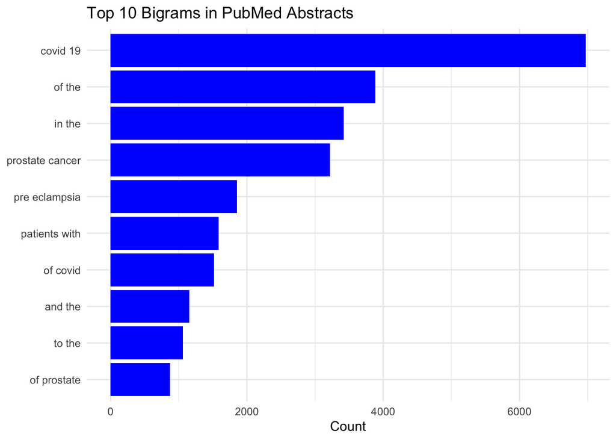

```r
top10_bigrams %>%
  mutate(bigram = fct_reorder(bigram, n)) %>%
  ggplot(aes(x = bigram, y = n)) +
  geom_col(fill = "blue") +
  coord_flip() +
  labs(title = "Top 10 Bigrams in PubMed Abstracts",
       x = NULL, y = "Count") +
  theme_minimal()
```

**Answer**: The most frequent bigram is “covid 19”, which reflects the large number of COVID abstracts. Other top bigrams such as ‘prostate cancer’ and “preeclampsia” highlight disease‑specific focus, while generic bigrams like “of the” and “in the” reflect common scientific phrasing

## Question 4

```r
# Count tokens per term (stop words already removed)
term_token_counts <- tokens_nostop %>%
  count(term, token, sort = FALSE)

# Calculate TF–IDF
tfidf <- term_token_counts %>%
  bind_tf_idf(token, term, n)

# Top 5 tokens per term by TF–IDF
top5_tfidf <- tfidf %>%
  group_by(term) %>%
  slice_max(order_by = tf_idf, n = 5) %>%
  ungroup()

top5_tfidf
```

```
# A tibble: 25 × 6
   term            token           n      tf   idf  tf_idf
   <chr>           <chr>       <int>   <dbl> <dbl>   <dbl>
 1 covid           covid        7275 0.0736  1.61  0.118
 2 covid           pandemic      800 0.00810 1.61  0.0130
 3 covid           coronavirus   647 0.00655 1.61  0.0105
 4 covid           sars          372 0.00376 1.61  0.00606
 5 covid           cov           334 0.00338 1.61  0.00544
 6 cystic fibrosis cf            625 0.0244  0.916 0.0223
 7 cystic fibrosis fibrosis      867 0.0338  0.511 0.0173
 8 cystic fibrosis cystic        862 0.0336  0.511 0.0172
 9 cystic fibrosis cftr           86 0.00335 1.61  0.00539
10 cystic fibrosis sweat          83 0.00323 1.61  0.00521
# ℹ 15 more rows
```

**Answer:** Below are the top 5 tokens from each search term with the highest TF-IDF value:

1. **Covid**: COVID, pandemic, coronavirus, SARS, cov
2. **Cystic Fibrosis**: cf, fibrosis, cystic, cftr, sweat
3. **Meningitis:** meningitis, meningeal, pachymeningitis, csf, meninges
4. **Preeclampsia:** eclampsia, preeclampsia, pregnancy, maternal, gestational
5. **Prostate** **Cancer**: prostate, androgen, psa, prostatectomy, castration

Compared to the raw frequency results in Question 1, which were dominated by stop words and generic scientific terms (ex. “the”, “of”, “in”, “patients”), the TF–IDF results are much more informative. TF–IDF down‑weights common words that appear across all abstracts and instead highlights tokens that are uniquely associated with each search term.

# Sentiment Analysis

## Question 5

```r
nrc <- get_sentiments("nrc")

nrc_counts <- tokens_nostop %>%
  inner_join(nrc, by = c("token" = "word")) %>%
  count(term, sentiment, sort = TRUE)

# Most common sentiment per term
most_common_nrc <- nrc_counts %>%
  group_by(term) %>%
  slice_max(order_by = n, n = 1, with_ties = FALSE) %>%
  ungroup()

most_common_nrc %>% gt() %>%
  tab_header(title = md("Most common NRC sentiment by search term")) %>%
  fmt_number(columns = n, sep_mark = ",")
```

Most common NRC sentiment by search term

| term | sentiment | n |
| --- | --- | --- |
| covid | positive | 9,254.00 |
| cystic fibrosis | positive | 2,564.00 |
| meningitis | negative | 1,959.00 |
| preeclampsia | positive | 7,603.00 |
| prostate cancer | negative | 8,799.00 |

**Answer:** Using the NRC lexicon, the most common sentiment for each search term was identified. COVID, cystic fibrosis, and preeclampsia abstracts were considered “positive” sentiment words, while prostate cancer and meningitis abstracts were dominated by “negative” sentiment words. Specifically, COVID had the highest number of positive sentiment tokens (9,254), preeclampsia also showed a strong positive signal (7,603), and cystic fibrosis leaned positive (2,564). In contrast, prostate cancer (8,799) and meningitis (1,959) were most associated with negative sentiment words.

This suggests that while some conditions are described with more positive or neutral biomedical language, others are more often framed in negative contexts, possibly reflecting the severity or clinical framing of those diseases.

```r
# Excluding positive/negative
nrc_counts %>%
  filter(!sentiment %in% c("positive", "negative")) %>%
  group_by(term) %>%
  slice_max(order_by = n, n = 1)
```

```
# A tibble: 5 × 3
# Groups:   term [5]
  term            sentiment        n
  <chr>           <chr>        <int>
1 covid           fear          7373
2 cystic fibrosis disgust       1714
3 meningitis      fear          1371
4 preeclampsia    anticipation  4555
5 prostate cancer fear          8039
```

**Answer:** When excluding the broad categories of “positive” and “negative”, the NRC lexicon highlights more specific emotional associations for each condition. COVID, prostate cancer, and meningitis abstracts were most strongly linked with *fear*, reflecting the uncertainty and risk emphasized in these diseases. Cystic fibrosis abstracts are most associated with *disgust*, which may reflect language around symptoms or pathology. Lastly, preeclampsia abstracts are dominated by *anticipation*, likely tied to pregnancy‑related contexts and the forward‑looking nature of maternal health research.

These results suggest that once general polarity is removed, the NRC lexicon captures more nuanced emotional tones that differ across conditions.

## Question 6

```r
afinn <- get_sentiments("afinn")

afinn_scores <- pubmed_clean %>%
  unnest_tokens(output = "token", input = abstract, token = "words") %>%
  inner_join(afinn, by = c("token" = "word")) %>%
  group_by(abstract_id, term) %>%
  summarise(afinn_score = mean(value), .groups = "drop")

glimpse(afinn_scores)
```

```
Rows: 3,163
Columns: 3
$ abstract_id <int> 1, 2, 3, 4, 5, 6, 7, 8, 9, 10, 11, 12, 13, 14, 15, 16, 17,…
$ term        <chr> "covid", "covid", "covid", "covid", "covid", "covid", "cov…
$ afinn_score <dbl> -1.1333333, -2.0000000, 0.2142857, -0.8000000, -1.6666667,…
```

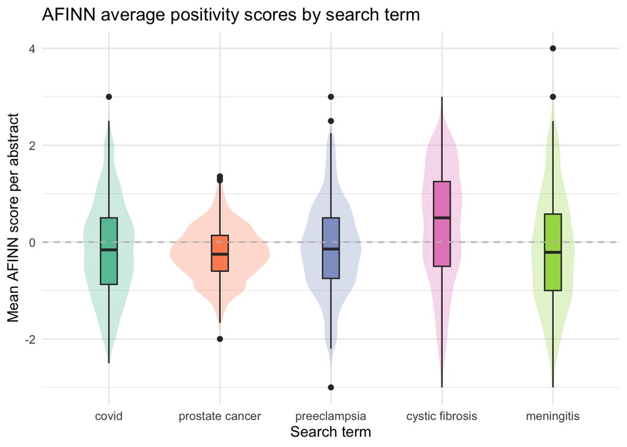

```r
afinn_scores %>%
  mutate(term = fct_infreq(term)) %>%
  ggplot(aes(x = term, y = afinn_score, fill = term)) +
  geom_violin(alpha = 0.3, color = NA) +
  geom_boxplot(width = 0.15, outlier_alpha = 0.3) +
  geom_hline(yintercept = 0, linetype = "dashed", color = "gray") +
  scale_fill_brewer(palette = "Set2", guide = "none") +
  labs(
    title = "AFINN average positivity scores by search term",
    x = "Search term",
    y = "Mean AFINN score per abstract"
  ) +
  theme_minimal(base_size = 12)
```

Overall, the AFINN results suggest that biomedical abstracts are generally written in neutral, technical language, but there are also subtle differences in sentiment emerge which depends on the condition being studied.